# MITxweek-7

# Crime in state = 2, subset

```r
kentucky <- subset(parole, state == 2)
View(kentucky)
table(kentucky$crime)
```

```
##
##  1  2  3  4
## 42 10 64  4
```

# Creating basic histograms

Recall from lecture that in ggplot, we need to specify the dataset, the aesthetic, and the geometry. To create a histogram, the geometry will be geom_histogram. The data we’ll use is parole, and the aesthetic will be the map from a variable to the x-axis of the histogram.

Create a histogram to find out the distribution of the age of parolees, by typing the following command in your R console (you might need to load the ggplot2 package first by typing library(ggplot2) in your R console):

ggplot(data = parole, aes(x = age)) + geom_histogram(binwidth = 5, boundary = 0, color = ‘black’, fill = ‘cornflowerblue’)

What is the age bracket with the most parolees?

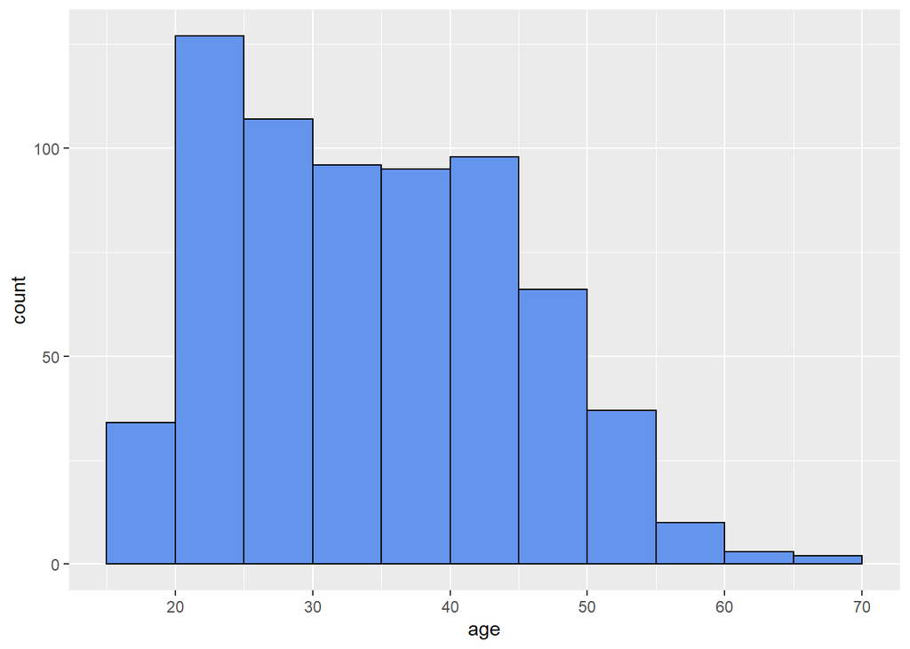

```r
ggplot(data = parole, aes(x = age)) +
  geom_histogram(binwidth = 5, boundary = 0, color = 'black', fill = 'cornflowerblue')
```

Redo

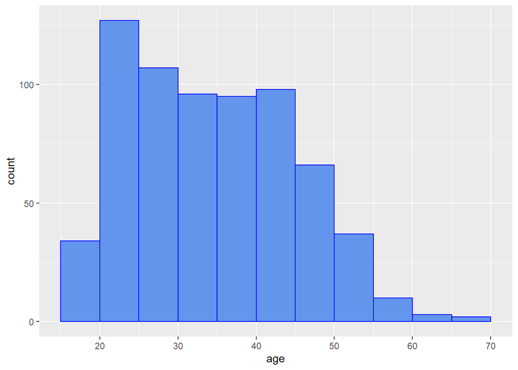

```r
ggplot(data = parole, aes(x = age)) +
  geom_histogram(binwidth = 5, boundary = 0, color = 'blue', fill = 'cornflowerblue')
```

# Adding another dimension

Now suppose we are interested in seeing how the age distribution of male parolees compares to the age distribution of female parolees.

One option would be to create a heatmap with age on one axis and male (a binary variable in our data set) on the other axis. Another option would be to stick with histograms, but to create a separate histogram for each gender. ggplot has the ability to do this automatically using the facet_grid command.

To create separate histograms for male and female, type the following command into your R console:

ggplot(data = parole, aes(x = age)) + geom_histogram(binwidth = 5, boundary = 0) + facet_grid(male ~ .)

The histogram for female parolees is shown at the top, and the histogram for male parolees is shown at the bottom.

What is the age bracket with the most female parolees?

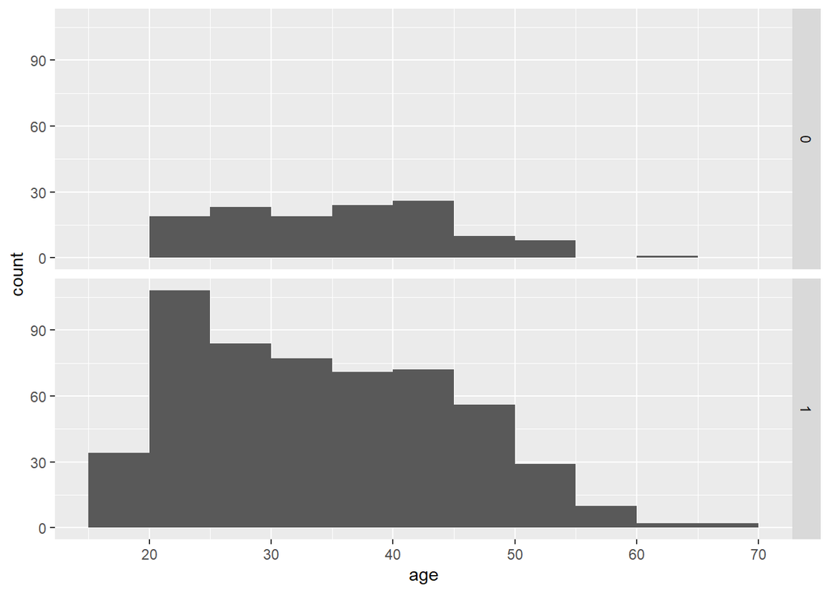

```r
ggplot(data = parole, aes(x = age)) +
  geom_histogram(binwidth = 5, boundary = 0) + facet_grid(male ~ .)
```

Redo

Now change the facet_grid argument to be “.~male” instead of “male~.”. What does this do?

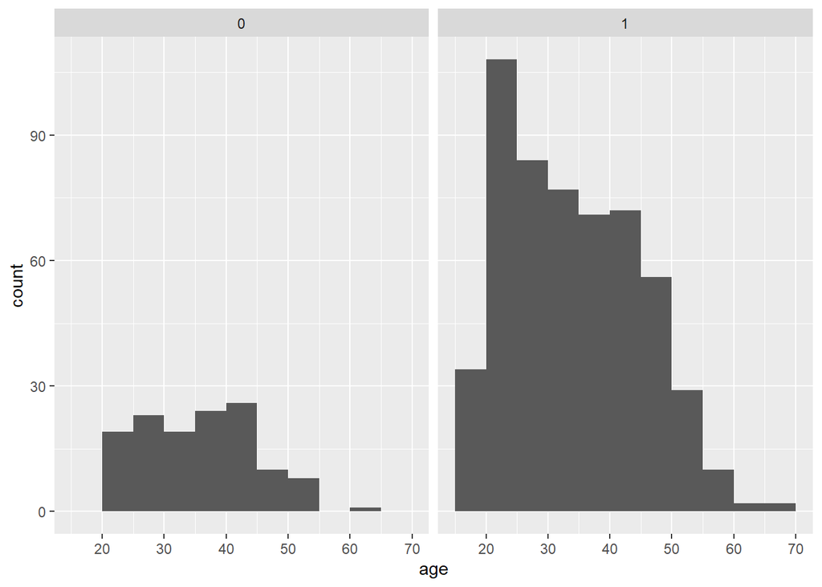

```r
ggplot(data = parole, aes(x = age)) +
  geom_histogram(binwidth = 5, boundary = 0) + facet_grid(.~ male)
```

# Adding another Dimension

An alternative to faceting is to simply color the different groups differently. To color the data points by group, we need to tell ggplot that a property of the data (male or not male) should be translated to an aesthetic property of the histogram. We can do this by setting the fill parameter within the aesthetic to male.

Run the following command in your R console to produce a histogram where data points are colored by group:

ggplot(data = parole, aes(x = age, fill = male)) + geom_histogram(binwidth = 5, boundary = 0)

Since we didn’t specify colors to use, ggplot will use its default color selection. Let’s change this by defining our own color palette. First, type in your R console:

colorPalette = c(“#000000”, “#E69F00”, “#56B4E9”, “#009E73”, “#F0E442”, “#0072B2”, “#D55E00”, “#CC79A7”)

This is actually a colorblind-friendly palette, desribed on this Cookbook for R page . Now, generate your histogram again, using colorPalette, with the following command:

ggplot(data = parole, aes(x = age, fill = male)) + geom_histogram(binwidth = 5, boundary = 0) + scale_fill_manual(values=colorPalette)

What color is the histogram for the female parolees?

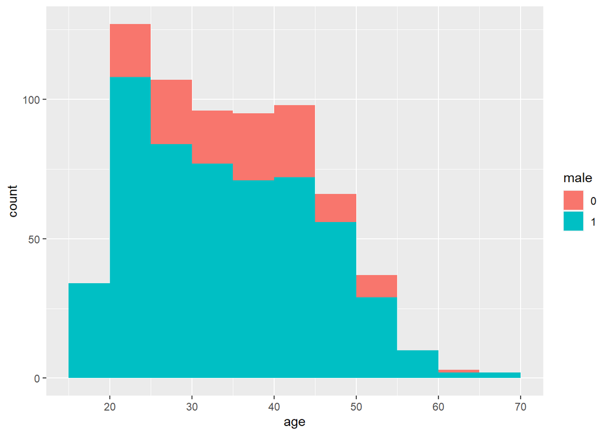

```r
ggplot(data = parole, aes(x = age, fill = male)) +
  geom_histogram(binwidth = 5, boundary = 0)
```

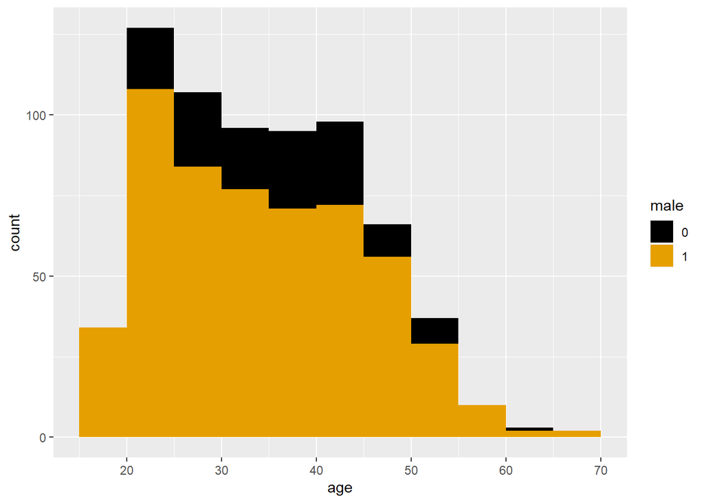

```r
colorPalette = c("#000000", "#E69F00", "#56B4E9", "#009E73", "#F0E442", "#0072B2", "#D55E00", "#CC79A7")

ggplot(data = parole, aes(x = age, fill = male)) +
  geom_histogram(binwidth = 5, boundary = 0) + scale_fill_manual(values=colorPalette)
```

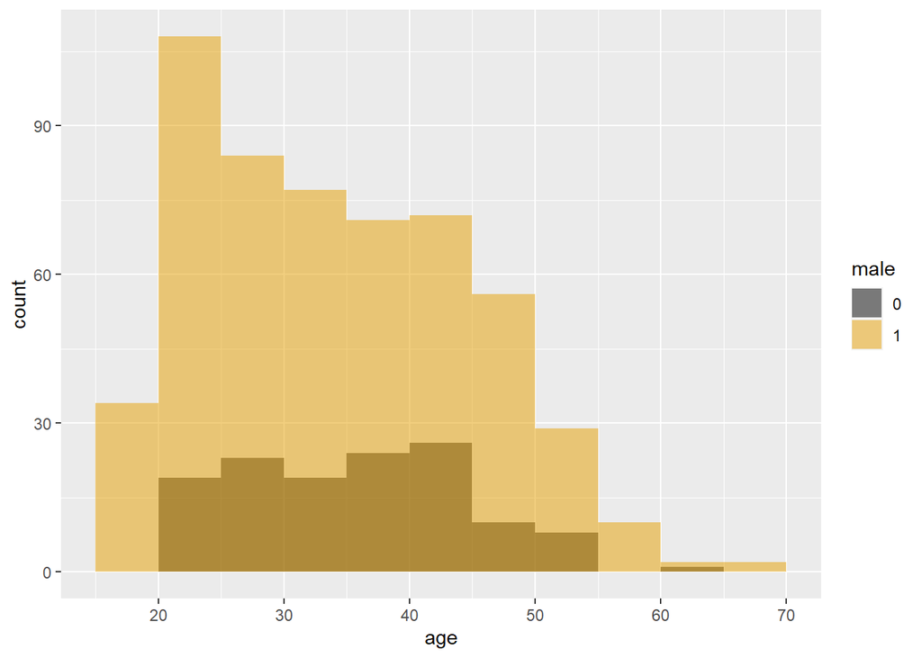

```r
# dont stack them

ggplot(data = parole, aes(x = age, fill = male)) +
  geom_histogram(binwidth = 5, boundary = 0, position = "identity", alpha = 0.5) + scale_fill_manual(values=colorPalette)
```

# TIme saved: another histogram

Now let’s explore another aspect of the data: the amount of time served by parolees. Create a basic histogram like the one we created in Problem 2, but this time with time.served on the x-axis. Set the bin width to one month.

What is the most common length of time served, according to this histogram?

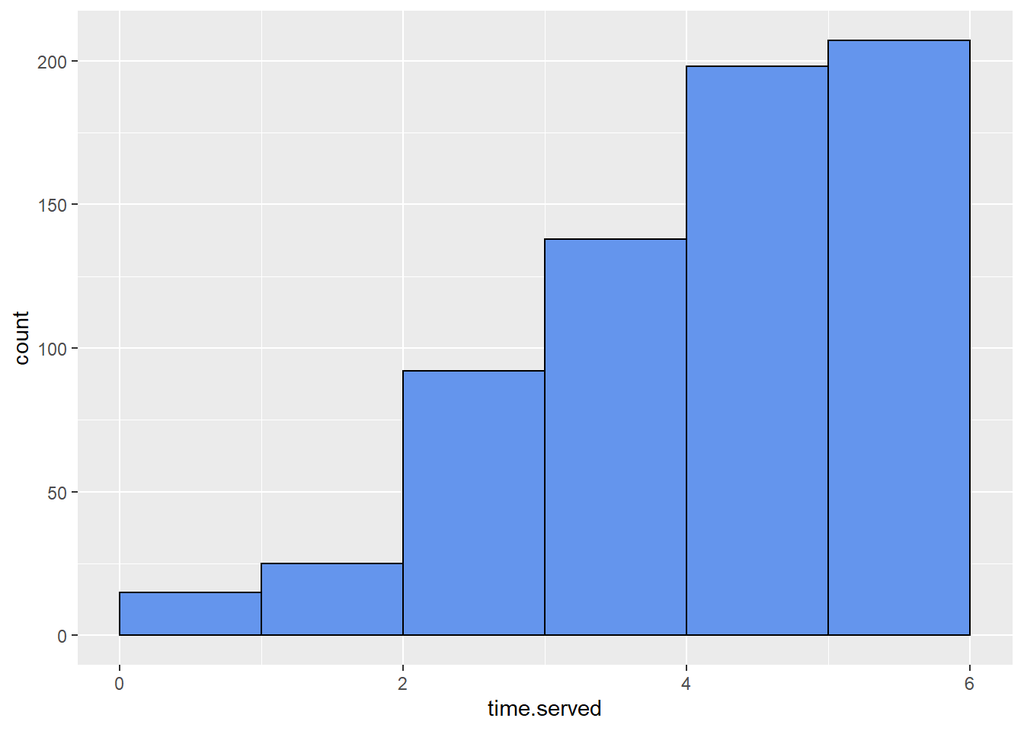

```r
ggplot(data = parole, aes(x = time.served)) +
  geom_histogram(binwidth = 1, boundary = 0, color = 'black', fill = 'cornflowerblue')
```

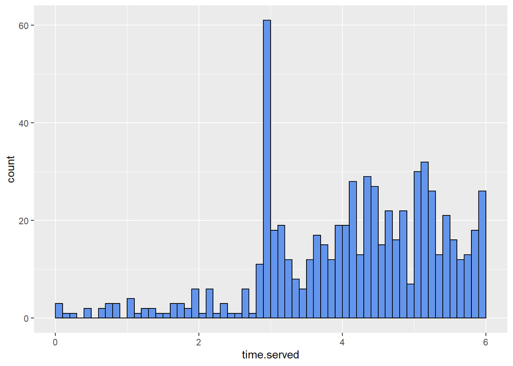

```r
# bin  = 0.1 month

ggplot(data = parole, aes(x = time.served)) +
  geom_histogram(binwidth = 0.1, boundary = 0, color = 'black', fill = 'cornflowerblue')
```

# faceting with type of crime

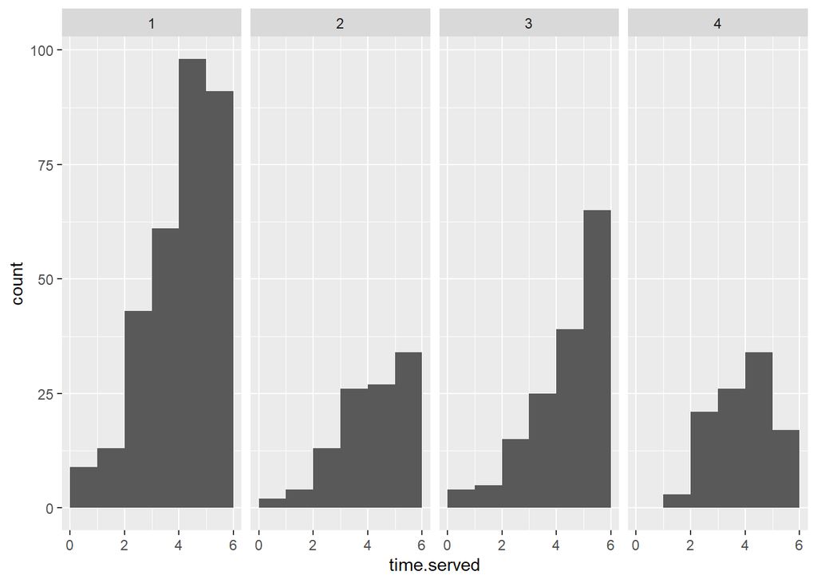

```r
ggplot(data = parole, aes(x = time.served)) +
  geom_histogram(binwidth = 1, boundary = 0) + facet_grid(.~ crime)
```

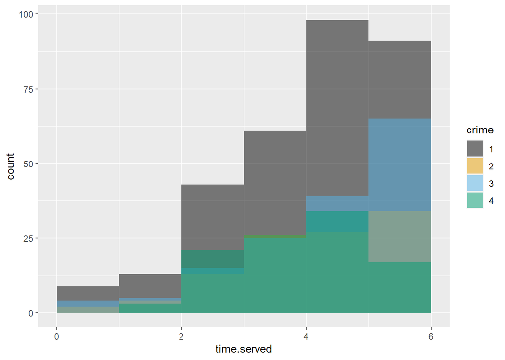

```r
# when we overlay them
ggplot(data = parole, aes(x = time.served, fill = crime)) +
  geom_histogram(binwidth = 1, boundary = 0, position = "identity", alpha = 0.5) + scale_fill_manual(values=colorPalette)
```